# Self-Driving Car Engineer Nanodegree

I decided to augment images from the following classes:  
**(19)** Dangerous curve to the left  
**(41)** End of no passing  
**(23)** Slippery road  
**(42)** End of no passing by vehicles over 3.5 metric ...  
**(30)** Beware of ice/snow  
**(28)** Childrens crossing  
**(26)** Traffic signals  
Besides that, I'm going to augment all images wich have a count of less than 400 in the training set. Thus obtaining a more balanced dataset.  
**24,27,0,37,32,39,21,40,20,36,22,6,16,34,30**

```
Classes which got more often misclassified:
```

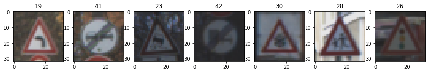

```
Underepresented classes (<400):
```

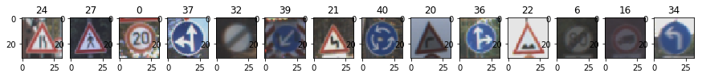

```python
# Print each class
print('Classes which got more often misclassified:')
plt.figure(figsize=(15,15))
for i in range(7):
    classes = np.array([19,41,23,42,30,28,26])
    d = np.where(y_train == classes[i])[0][80]
    plt.subplot(1,7,i+1)
    plt.title(y_train[d])
    plt.imshow(X_train_plain[d])
plt.show()

print('Underepresented classes (<400):')
plt.figure(figsize=(15,15))
for i in range(14):
    classes = np.array([24,27,0,37,32,39,21,40,20,36,22,6,16,34])
    d = np.where(y_train == classes[i])[0][80]
    plt.subplot(1,14,i+1)
    plt.title(y_train[d])
    plt.imshow(X_train_plain[d])
plt.show()
```

Several characteristics can be observed:  
Classes are y-symmetric to each other (e.g. 36<->37). Classes are y-symmetric with themself (e.g. 30,22). Classes are 180° rotation invariant (e.g. 32,6) etc.

```python
# Image augmentation

def gamma_correction(img, correction):
    img = img/255.0
    img = cv2.pow(img, correction)
    return np.uint8(img*255)

def flipping_symm_class(X_train, y_train, classes, new_classes = None, flip_other=False, plot=False):
    new_images = []
    new_labels = []
    for j in range(len(classes)):
        indices = np.where(y_train == classes[j])
        X_train_part = X_train[indices]
        for i in range(len(X_train_part)):
            img_flipped = cv2.flip(X_train_part[i],1)
            if plot:
                if i == 0:
                    plt.figure(figsize=(5,5))
                plt.subplot(1,4,i+1)
                if flip_other:
                    plt.title(str(classes[j])+' -> '+str(new_classes[j]))
                else:
                    plt.title(classes[j])
                both = np.concatenate((X_train_part[i], img_flipped), axis=0)
                plt.imshow(both)
                if i == 2 and classes[-1] == classes[j] and flip_other:
                    return print('Flipped images from class(es):', classes, ' to class(es):', new_classes)
                if i == 2 and classes[-1] == classes[j]:
                    return print('Flipped images from class(es):', classes)
                if i == 2:
                    break
            new_images.append(img_flipped)
            if flip_other:
                new_labels.append(new_classes[j])
            else:
                new_labels.append(classes[j])
    new_images = np.array(new_images)
    new_labels = np.array(new_labels)
    X_train_new = np.concatenate((X_train, new_images))
    y_train_new = np.concatenate((y_train, new_labels))
    return X_train_new, y_train_new

def rotate_bright(X_train, y_train, classes, plot=False):
    new_images = []
    new_labels = []
    img = X_train[0]
    img_center = tuple(np.array(img.shape[:2])/2)
    for label in classes:
        indices = np.where(y_train == label)
        X_train_part = X_train[indices]
        for i in range(len(X_train_part)):
            angle = np.random.uniform(-30,30)
            rot_mat = cv2.getRotationMatrix2D(img_center,angle,1.0)
            result = cv2.warpAffine(X_train_part[i], rot_mat, img.shape[:2],flags=cv2.INTER_LINEAR)
            value = np.random.uniform(0.2,1.5)
            if value > 0.8 and value < 1.1:
                value -= 0.4
            new_img = gamma_correction(result, value)
            if plot:
                if i == 0:
                    plt.figure(figsize=(5,5))
                plt.subplot(1,4,i+1)
                plt.title(label)
                result = cv2.warpAffine(X_train_part[i+100], rot_mat, img.shape[:2],flags=cv2.INTER_LINEAR)
                new_img = gamma_correction(result, value)
                both = np.concatenate((X_train_part[i+100], new_img), axis=0)
                plt.imshow(both)
                if i == 2 and classes[-1] == label:
                    return print('Rotated+brightness images from class(es):', classes)
                if i == 2:
                    break
            new_images.append(new_img)
            new_labels.append(label)
    new_images = np.array(new_images)
    new_labels = np.array(new_labels)
    X_train_new = np.concatenate((X_train, new_images))
    y_train_new = np.concatenate((y_train, new_labels))
    return X_train_new, y_train_new

def rot_180(X_train, y_train, classes, plot=False):
    new_images = []
    new_labels = []
    for label in classes:
        indices = np.where(y_train == label)
        X_train_part = X_train[indices]
        for i in range(len(X_train_part)):
            img_new = cv2.flip(X_train_part[i],1)
            flipped_2 = cv2.flip(img_new,0)
            if plot:
                if i == 0:
                    plt.figure(figsize=(5,5))
                plt.subplot(1,4,i+1)
                plt.title(label)
                both = np.concatenate((X_train_part[i], flipped_2), axis=0)
                plt.imshow(both)
                if i == 2 and label == classes[-1]:
                    return print('2 times flipped images from class(es):', classes)
                if i == 2:
                    break
            new_images.append(flipped_2)
            new_labels.append(label)
    new_images = np.array(new_images)
    new_labels = np.array(new_labels)
    X_train_new = np.concatenate((X_train, new_images))
    y_train_new = np.concatenate((y_train, new_labels))
    return X_train_new, y_train_new
```

```python
# Load pickled data
import pickle

# Fill this in based on where you saved the training and testing data

training_file = 'data/train.p'
validation_file = 'data/valid.p'
testing_file = 'data/test.p'

with open(training_file, mode='rb') as f:
    train = pickle.load(f)
with open(validation_file, mode='rb') as f:
    valid = pickle.load(f)
with open(testing_file, mode='rb') as f:
    test = pickle.load(f)

X_train, y_train = train['features'], train['labels']
X_valid, y_valid = valid['features'], valid['labels']
X_test, y_test = test['features'], test['labels']
```

```
Flipped images from class(es): [36, 33]  to class(es): [37, 34]
Flipped images from class(es): [30, 22]
Rotated+brightness images from class(es): [23, 21]
2 times flipped images from class(es): [32, 41]
```

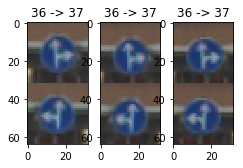

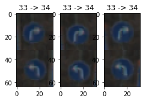

[figure not shown]

[figure not shown]

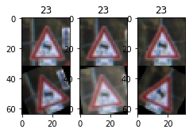

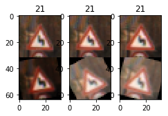

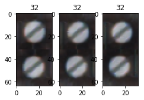

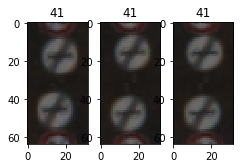

```python
# Plot some augmentation examples

# 2 Symmetric classes
flipping_symm_class(X_train, y_train, [36,33], new_classes = [37,34], flip_other=True, plot=True)

# Self symmetric class
flipping_symm_class(X_train, y_train, [30,22], flip_other=False, plot=True)

# Rotation + brighntess change
rotate_bright(X_train, y_train, [23,21], True)

# 180° rotation (flip horitontal + vertical)
rot_180(X_train, y_train, [32,41], True)
```

```python
# Applying augmentation to the dataset
X_train_aug, y_train_aug = flipping_symm_class(X_train, y_train, [30,22,26], new_classes = None, flip_other=False, plot=False)
X_train_aug, y_train_aug = flipping_symm_class(X_train_aug, y_train_aug, [36,37,38,33,19,20], new_classes = [37,36,39,34,20,19], flip_other=True, plot=False)
X_train_aug, y_train_aug = rot_180(X_train_aug, y_train_aug, [32,41], plot=False)
X_train_aug, y_train_aug = rotate_bright(X_train_aug, y_train_aug, [24,27,23,28,29,0,42,21,40,6,16,32,41,30,22,37,36,20,19], plot=False)
# Normalizing
X_train_aug = normalize(X_train_aug)
```

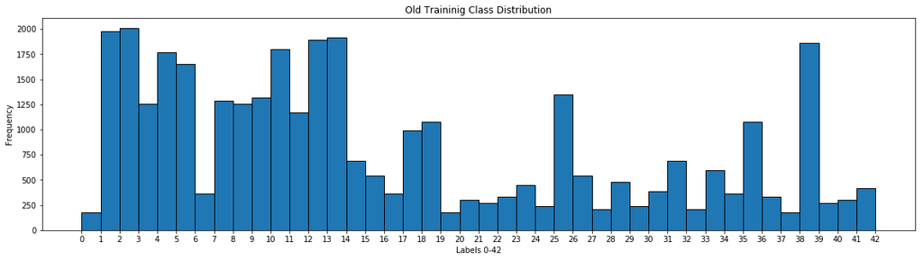

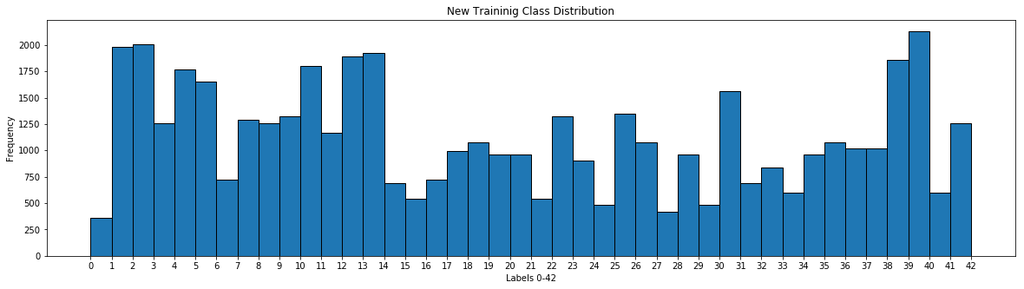

```python
# Plot new class distribution
hist_distro(y_train, "Old Traininig Class Distribution")
hist_distro(y_train_aug, "New Traininig Class Distribution")
```

Now training the network again with the newly created data and more epochs. First normal model (both conv filter doubled) with plain RGB data **without** augmentation.

```
Training with  Model_normal_large parameters.
Training...
EPOCH 1 ...
Training Accuracy = 0.256
Training Loss = 0.00555
Validation Accuracy = 0.220
Validation Loss = 0.00608
EPOCH 2 ...
Training Accuracy = 0.423
Training Loss = 0.00383
Validation Accuracy = 0.375
Validation Loss = 0.00431
EPOCH 3 ...
Training Accuracy = 0.533
Training Loss = 0.00290
Validation Accuracy = 0.488
Validation Loss = 0.00332
EPOCH 4 ...
Training Accuracy = 0.628
Training Loss = 0.00234
Validation Accuracy = 0.581
Validation Loss = 0.00274
EPOCH 5 ...
Training Accuracy = 0.683
Training Loss = 0.00193
Validation Accuracy = 0.642
Validation Loss = 0.00237
EPOCH 6 ...
Training Accuracy = 0.735
Training Loss = 0.00164
Validation Accuracy = 0.680
Validation Loss = 0.00209
EPOCH 7 ...
Training Accuracy = 0.760
Training Loss = 0.00146
Validation Accuracy = 0.710
Validation Loss = 0.00193
EPOCH 8 ...
Training Accuracy = 0.796
Training Loss = 0.00128
```

[output cut: 68 more lines]

```
Training Accuracy = 0.984
Training Loss = 0.00009
Validation Accuracy = 0.939
Validation Loss = 0.00067
EPOCH 140 ...
Training Accuracy = 0.986
Training Loss = 0.00009
Validation Accuracy = 0.939
Validation Loss = 0.00083
EPOCH 150 ...
Training Accuracy = 0.987
Training Loss = 0.00009
Validation Accuracy = 0.941
Validation Loss = 0.00075
Model saved
```

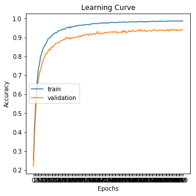

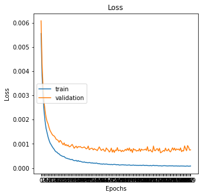

```python
import tensorflow as tf
import pathlib
from sklearn.utils import shuffle

# Adjusting learning rate
model_data_sets = [
             ('Model_normal_large', 'model_normal_large', 0.001)
            ]

# Hyperparameters
EPOCHS = 150
BATCH_SIZE = 512
keep_prob_value = 0.5 # Dropout
## Parameters for random weights/bias initialization
mu = 0
sigma = 0.1

for model, save_name, l_rate in model_data_sets:
    pathlib.Path(save_name + '_model').mkdir(parents=True, exist_ok=True)
    save_path = save_name + '_model/' + save_name + '.ckpt'

    # Placeholder
    x = tf.placeholder(tf.float32, (None, 32, 32, 3)) # Placeholder for train dataset
    y = tf.placeholder(tf.int32, (None)) # Placeholder for labels
    one_hot_y = tf.one_hot(y, nb_classes)
    keep_prob = tf.placeholder(tf.float32) # Dropout

    # Trainig pipeline
    logits = LeNet2(x, keep_prob, mu, sigma, 12, 32, 120, 84, conv3 = False)
    cross_entropy = tf.nn.softmax_cross_entropy_with_logits(labels=one_hot_y, logits=logits)
    loss_operation = tf.reduce_mean(cross_entropy)
    optimizer = tf.train.AdamOptimizer(learning_rate = l_rate)
    training_operation = optimizer.minimize(loss_operation)

    # Model evaluation
    correct_prediction = tf.equal(tf.argmax(logits, 1), tf.argmax(one_hot_y, 1))
    accuracy_operation = tf.reduce_mean(tf.cast(correct_prediction, tf.float32))

    print('Training with ', model, 'parameters.')
    saver = tf.train.Saver()
    train_acc_all, train_loss_all, valid_acc_all, valid_loss_all = train_model(X_train_plain, y_train, X_valid_plain, y_valid, saver, save_path)
    # Plot learning curves and loss
    plot_learning(train_acc_all, valid_acc_all)
    plot_loss(train_loss_all, valid_loss_all)
    print('-'*60)
```

And **with** augmentation.

```
Training with  Model_augment parameters.
Training...
EPOCH 1 ...
Training Accuracy = 0.278
Training Loss = 0.00519
Validation Accuracy = 0.269
Validation Loss = 0.00542
EPOCH 2 ...
Training Accuracy = 0.495
Training Loss = 0.00315
Validation Accuracy = 0.473
Validation Loss = 0.00339
EPOCH 3 ...
Training Accuracy = 0.618
Training Loss = 0.00232
Validation Accuracy = 0.589
Validation Loss = 0.00264
EPOCH 4 ...
Training Accuracy = 0.693
Training Loss = 0.00187
Validation Accuracy = 0.669
Validation Loss = 0.00218
EPOCH 5 ...
Training Accuracy = 0.746
Training Loss = 0.00155
Validation Accuracy = 0.711
Validation Loss = 0.00189
EPOCH 6 ...
Training Accuracy = 0.781
Training Loss = 0.00136
Validation Accuracy = 0.755
Validation Loss = 0.00164
EPOCH 7 ...
Training Accuracy = 0.802
Training Loss = 0.00121
Validation Accuracy = 0.770
Validation Loss = 0.00157
EPOCH 8 ...
Training Accuracy = 0.823
Training Loss = 0.00108
```

[output cut: 68 more lines]

```
Training Accuracy = 0.986
Training Loss = 0.00009
Validation Accuracy = 0.946
Validation Loss = 0.00082
EPOCH 140 ...
Training Accuracy = 0.984
Training Loss = 0.00010
Validation Accuracy = 0.939
Validation Loss = 0.00096
EPOCH 150 ...
Training Accuracy = 0.987
Training Loss = 0.00008
Validation Accuracy = 0.947
Validation Loss = 0.00097
Model saved
```

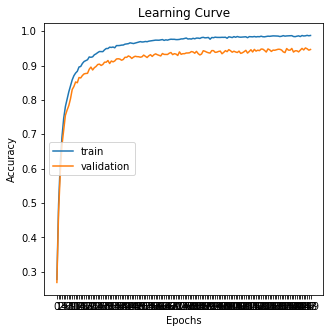

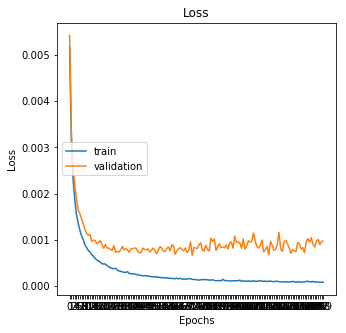

```python
import tensorflow as tf
import pathlib
from sklearn.utils import shuffle

# Adjusting learning rate
model_data_sets = [
             ('Model_augment', 'model_augment', 0.001)
            ]

# Hyperparameters
EPOCHS = 150
BATCH_SIZE = 512
keep_prob_value = 0.5 # Dropout
## Parameters for random weights/bias initialization
mu = 0
sigma = 0.1

for model, save_name, l_rate in model_data_sets:
    pathlib.Path(save_name + '_model').mkdir(parents=True, exist_ok=True)
    save_path = save_name + '_model/' + save_name + '.ckpt'

    # Placeholder
    x = tf.placeholder(tf.float32, (None, 32, 32, 3)) # Placeholder for train dataset
    y = tf.placeholder(tf.int32, (None)) # Placeholder for labels
    one_hot_y = tf.one_hot(y, nb_classes)
    keep_prob = tf.placeholder(tf.float32) # Dropout

    # Trainig pipeline
    logits = LeNet2(x, keep_prob, mu, sigma, 12, 32, 120, 84, conv3 = False)
    cross_entropy = tf.nn.softmax_cross_entropy_with_logits(labels=one_hot_y, logits=logits)
    loss_operation = tf.reduce_mean(cross_entropy)
    optimizer = tf.train.AdamOptimizer(learning_rate = l_rate)
    training_operation = optimizer.minimize(loss_operation)

    # Model evaluation
    correct_prediction = tf.equal(tf.argmax(logits, 1), tf.argmax(one_hot_y, 1))
    accuracy_operation = tf.reduce_mean(tf.cast(correct_prediction, tf.float32))

    print('Training with ', model, 'parameters.')
    saver = tf.train.Saver()
    train_acc_all, train_loss_all, valid_acc_all, valid_loss_all = train_model(X_train_aug, y_train_aug, X_valid_plain, y_valid, saver, save_path)
    # Plot learning curves and loss
    plot_learning(train_acc_all, valid_acc_all)
    plot_loss(train_loss_all, valid_loss_all)
    print('-'*60)
```

Going back to the other model forms, training with both convolution filters/dense neurons doubled:

```
Training with  Model_augment_doubled parameters.
Training...
EPOCH 1 ...
Training Accuracy = 0.384
Training Loss = 0.00428
Validation Accuracy = 0.364
Validation Loss = 0.00459
EPOCH 2 ...
Training Accuracy = 0.617
Training Loss = 0.00245
Validation Accuracy = 0.593
Validation Loss = 0.00270
EPOCH 3 ...
Training Accuracy = 0.726
Training Loss = 0.00171
Validation Accuracy = 0.688
Validation Loss = 0.00201
EPOCH 4 ...
Training Accuracy = 0.786
Training Loss = 0.00132
Validation Accuracy = 0.744
Validation Loss = 0.00175
EPOCH 5 ...
Training Accuracy = 0.836
Training Loss = 0.00105
Validation Accuracy = 0.789
Validation Loss = 0.00145
EPOCH 6 ...
Training Accuracy = 0.866
Training Loss = 0.00084
Validation Accuracy = 0.823
Validation Loss = 0.00122
EPOCH 7 ...
Training Accuracy = 0.888
Training Loss = 0.00074
Validation Accuracy = 0.835
Validation Loss = 0.00120
EPOCH 8 ...
Training Accuracy = 0.903
Training Loss = 0.00065
```

[output cut: 68 more lines]

```
Training Accuracy = 0.996
Training Loss = 0.00003
Validation Accuracy = 0.948
Validation Loss = 0.00095
EPOCH 140 ...
Training Accuracy = 0.996
Training Loss = 0.00002
Validation Accuracy = 0.959
Validation Loss = 0.00117
EPOCH 150 ...
Training Accuracy = 0.997
Training Loss = 0.00002
Validation Accuracy = 0.954
Validation Loss = 0.00106
Model saved
```

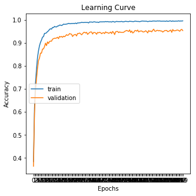

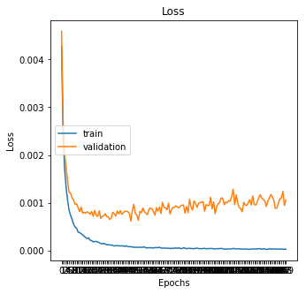

```python
import tensorflow as tf
import pathlib
from sklearn.utils import shuffle

# Adjusting learning rate
model_data_sets = [
             ('Model_augment_doubled', 'model_augment_doubled', 0.001)
            ]

# Hyperparameters
EPOCHS = 150
BATCH_SIZE = 512
keep_prob_value = 0.5 # Dropout
## Parameters for random weights/bias initialization
mu = 0
sigma = 0.1

for model, save_name, l_rate in model_data_sets:
    pathlib.Path(save_name + '_model').mkdir(parents=True, exist_ok=True)
    save_path = save_name + '_model/' + save_name + '.ckpt'

    # Placeholder
    x = tf.placeholder(tf.float32, (None, 32, 32, 3)) # Placeholder for train dataset
    y = tf.placeholder(tf.int32, (None)) # Placeholder for labels
    one_hot_y = tf.one_hot(y, nb_classes)
    keep_prob = tf.placeholder(tf.float32) # Dropout

    # Trainig pipeline
    logits = LeNet2(x, keep_prob, mu, sigma, 12, 32, 240, 168, conv3 = False)
    cross_entropy = tf.nn.softmax_cross_entropy_with_logits(labels=one_hot_y, logits=logits)
    loss_operation = tf.reduce_mean(cross_entropy)
    optimizer = tf.train.AdamOptimizer(learning_rate = l_rate)
    training_operation = optimizer.minimize(loss_operation)

    # Model evaluation
    correct_prediction = tf.equal(tf.argmax(logits, 1), tf.argmax(one_hot_y, 1))
    accuracy_operation = tf.reduce_mean(tf.cast(correct_prediction, tf.float32))

    print('Training with ', model, 'parameters.')
    saver = tf.train.Saver()
    train_acc_all, train_loss_all, valid_acc_all, valid_loss_all = train_model(X_train_aug, y_train_aug, X_valid_plain, y_valid, saver, save_path)
    # Plot learning curves and loss
    plot_learning(train_acc_all, valid_acc_all)
    plot_loss(train_loss_all, valid_loss_all)
    print('-'*60)
```

And with another convolution layer added:

```
Training with  Model_augment_conv3 parameters.
Training...
EPOCH 1 ...
Training Accuracy = 0.424
Training Loss = 0.00397
Validation Accuracy = 0.397
Validation Loss = 0.00430
EPOCH 2 ...
Training Accuracy = 0.663
Training Loss = 0.00212
Validation Accuracy = 0.642
Validation Loss = 0.00238
EPOCH 3 ...
Training Accuracy = 0.769
Training Loss = 0.00146
Validation Accuracy = 0.747
Validation Loss = 0.00171
EPOCH 4 ...
Training Accuracy = 0.829
Training Loss = 0.00109
Validation Accuracy = 0.800
Validation Loss = 0.00143
EPOCH 5 ...
Training Accuracy = 0.867
Training Loss = 0.00086
Validation Accuracy = 0.825
Validation Loss = 0.00117
EPOCH 6 ...
Training Accuracy = 0.889
Training Loss = 0.00072
Validation Accuracy = 0.846
Validation Loss = 0.00107
EPOCH 7 ...
Training Accuracy = 0.907
Training Loss = 0.00060
Validation Accuracy = 0.855
Validation Loss = 0.00100
EPOCH 8 ...
Training Accuracy = 0.918
Training Loss = 0.00055
```

[output cut: 68 more lines]

```
Training Accuracy = 0.997
Training Loss = 0.00002
Validation Accuracy = 0.955
Validation Loss = 0.00080
EPOCH 140 ...
Training Accuracy = 0.995
Training Loss = 0.00003
Validation Accuracy = 0.956
Validation Loss = 0.00082
EPOCH 150 ...
Training Accuracy = 0.997
Training Loss = 0.00002
Validation Accuracy = 0.960
Validation Loss = 0.00072
Model saved
```

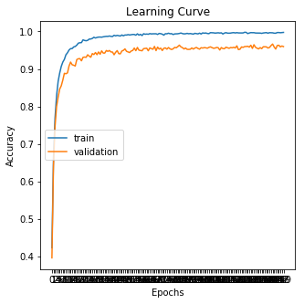

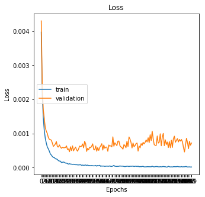

```python
import tensorflow as tf
import pathlib
from sklearn.utils import shuffle

# Adjusting learning rate
model_data_sets = [
             ('Model_augment_conv3', 'model_augment_conv3', 0.001)
            ]

# Hyperparameters
EPOCHS = 150
BATCH_SIZE = 512
keep_prob_value = 0.5 # Dropout
## Parameters for random weights/bias initialization
mu = 0
sigma = 0.1

for model, save_name, l_rate in model_data_sets:
    pathlib.Path(save_name + '_model').mkdir(parents=True, exist_ok=True)
    save_path = save_name + '_model/' + save_name + '.ckpt'

    # Placeholder
    x = tf.placeholder(tf.float32, (None, 32, 32, 3)) # Placeholder for train dataset
    y = tf.placeholder(tf.int32, (None)) # Placeholder for labels
    one_hot_y = tf.one_hot(y, nb_classes)
    keep_prob = tf.placeholder(tf.float32) # Dropout

    # Trainig pipeline
    logits = LeNet2(x, keep_prob, mu, sigma, 12, 32, 240, 168, conv3 = True)
    cross_entropy = tf.nn.softmax_cross_entropy_with_logits(labels=one_hot_y, logits=logits)
    loss_operation = tf.reduce_mean(cross_entropy)
    optimizer = tf.train.AdamOptimizer(learning_rate = l_rate)
    training_operation = optimizer.minimize(loss_operation)

    # Model evaluation
    correct_prediction = tf.equal(tf.argmax(logits, 1), tf.argmax(one_hot_y, 1))
    accuracy_operation = tf.reduce_mean(tf.cast(correct_prediction, tf.float32))

    print('Training with ', model, 'parameters.')
    saver = tf.train.Saver()
    train_acc_all, train_loss_all, valid_acc_all, valid_loss_all = train_model(X_train_aug, y_train_aug, X_valid_plain, y_valid, saver, save_path)
    # Plot learning curves and loss
    plot_learning(train_acc_all, valid_acc_all)
    plot_loss(train_loss_all, valid_loss_all)
    print('-'*60)
```

Doubling conv filters again.

```
Training with  Model_augment_conv3 parameters.
Training...
EPOCH 1 ...
Training Accuracy = 0.419
Training Loss = 0.00418
Validation Accuracy = 0.405
Validation Loss = 0.00446
EPOCH 2 ...
Training Accuracy = 0.676
Training Loss = 0.00205
Validation Accuracy = 0.661
Validation Loss = 0.00230
EPOCH 3 ...
Training Accuracy = 0.804
Training Loss = 0.00126
Validation Accuracy = 0.777
Validation Loss = 0.00149
EPOCH 4 ...
Training Accuracy = 0.856
Training Loss = 0.00091
Validation Accuracy = 0.832
Validation Loss = 0.00113
EPOCH 5 ...
Training Accuracy = 0.903
Training Loss = 0.00064
Validation Accuracy = 0.870
Validation Loss = 0.00089
EPOCH 6 ...
Training Accuracy = 0.916
Training Loss = 0.00056
Validation Accuracy = 0.885
Validation Loss = 0.00083
EPOCH 7 ...
Training Accuracy = 0.930
Training Loss = 0.00044
Validation Accuracy = 0.901
Validation Loss = 0.00073
EPOCH 8 ...
Training Accuracy = 0.949
Training Loss = 0.00034
```

[output cut: 71 more lines]

```
Validation Loss = 0.00050
EPOCH 140 ...
Training Accuracy = 0.997
Training Loss = 0.00002
Validation Accuracy = 0.971
Validation Loss = 0.00045
EPOCH 150 ...
Training Accuracy = 0.998
Training Loss = 0.00002
Validation Accuracy = 0.970
Validation Loss = 0.00056

Max train accuracy:  0.999094508086 at EPOCH:  145
Max validation accuracy:  0.97528344828 at EPOCH:  148
Model saved
```

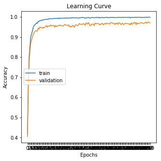

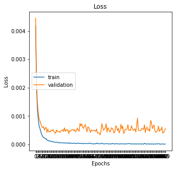

```python
import tensorflow as tf
import pathlib
from sklearn.utils import shuffle

# Adjusting learning rate
model_data_sets = [
             ('Model_augment_conv3', 'model_augment_conv3', 0.001)
            ]

# Hyperparameters
EPOCHS = 150
BATCH_SIZE = 512
keep_prob_value = 0.5 # Dropout
## Parameters for random weights/bias initialization
mu = 0
sigma = 0.1

for model, save_name, l_rate in model_data_sets:
    pathlib.Path(save_name + '_model').mkdir(parents=True, exist_ok=True)
    save_path = save_name + '_model/' + save_name + '.ckpt'

    # Placeholder
    x = tf.placeholder(tf.float32, (None, 32, 32, 3)) # Placeholder for train dataset
    y = tf.placeholder(tf.int32, (None)) # Placeholder for labels
    one_hot_y = tf.one_hot(y, nb_classes)
    keep_prob = tf.placeholder(tf.float32) # Dropout

    # Trainig pipeline
    logits = LeNet2(x, keep_prob, mu, sigma, 24, 64, 240, 168, conv3 = True)
    cross_entropy = tf.nn.softmax_cross_entropy_with_logits(labels=one_hot_y, logits=logits)
    loss_operation = tf.reduce_mean(cross_entropy)
    optimizer = tf.train.AdamOptimizer(learning_rate = l_rate)
    training_operation = optimizer.minimize(loss_operation)

    # Model evaluation
    correct_prediction = tf.equal(tf.argmax(logits, 1), tf.argmax(one_hot_y, 1))
    accuracy_operation = tf.reduce_mean(tf.cast(correct_prediction, tf.float32))

    print('Training with ', model, 'parameters.')
    saver = tf.train.Saver()
    train_acc_all, train_loss_all, valid_acc_all, valid_loss_all = train_model(X_train_aug, y_train_aug, X_valid_plain, y_valid, saver, save_path)
    # Plot learning curves and loss
    plot_learning(train_acc_all, valid_acc_all)
    plot_loss(train_loss_all, valid_loss_all)
    print('-'*60)
```

Images which still got misclassified:

```
Validation Accuracy = 0.968
Misclassified images in Validation set:
```

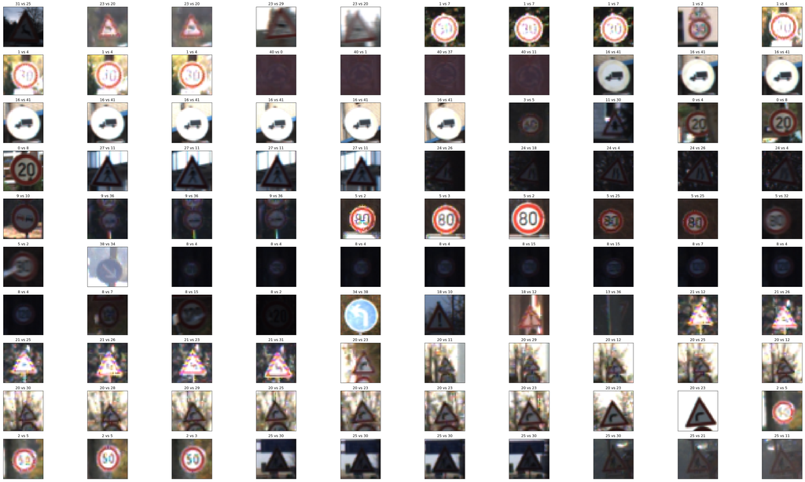

```python
X_valid_plain = X_valid.copy()
wrong_images = []
class_pred, class_true = [], []
_y = tf.nn.softmax(logits=logits)
saver = tf.train.Saver()
with tf.Session() as sess:
    checkpnt = tf.train.latest_checkpoint('./model_augment_conv3_model/')
    saver.restore(sess, './model_augment_conv3_model/model_augment_conv3.ckpt')
    valid_accuracy, b = evaluate(X_valid_plain, y_valid)
    print("Validation Accuracy = {:.3f}".format(valid_accuracy))
    for i in range(len(X_valid_plain)):
        new_img = np.expand_dims(X_valid_plain[i],0)
        predictions = sess.run([_y],feed_dict={x: new_img, keep_prob: 1.0})
        pred = np.argmax(predictions)
        if pred != y_valid[i]:
            wrong_images.append(X_valid_plain[i])
            class_true.append(y_valid[i])
            class_pred.append(pred)
wrong_images = np.array(wrong_images)
print("Misclassified images in Validation set:")
plt.figure(figsize=(50,50))
for i in range(len(wrong_images)):
    plt.subplot(17,len(wrong_images)//10,i+1)
    plt.xticks([])
    plt.yticks([])
    plt.title(str(class_true[i]) + ' vs ' + str(class_pred[i]))
    plt.imshow(wrong_images[i])
plt.show()
```

Don't augment classes 16, 20 (only flipping with 19), 21 and 41 (only flip 2 times).

```python
# Applying augmentation to the dataset
X_train_aug, y_train_aug = flipping_symm_class(X_train, y_train, [30,22,26], new_classes = None, flip_other=False, plot=False)
X_train_aug, y_train_aug = flipping_symm_class(X_train_aug, y_train_aug, [36,37,38,33,19,20], new_classes = [37,36,39,34,20,19], flip_other=True, plot=False)
X_train_aug, y_train_aug = rot_180(X_train_aug, y_train_aug, [32,41], plot=False)
X_train_aug, y_train_aug = rotate_bright(X_train_aug, y_train_aug, [24,27,23,28,29,0,42,40,6,32,30,22,37,36,19], plot=False)
# Normalizing
X_train_aug = normalize(X_train_aug)
```

```
Training with  Model_augment2_conv3 parameters.
Training...
EPOCH 1 ...
Training Accuracy = 0.401
Training Loss = 0.00424
Validation Accuracy = 0.389
Validation Loss = 0.41361
EPOCH 2 ...
Training Accuracy = 0.651
Training Loss = 0.00218
Validation Accuracy = 0.617
Validation Loss = 0.21325
EPOCH 3 ...
Training Accuracy = 0.783
Training Loss = 0.00138
Validation Accuracy = 0.706
Validation Loss = 0.17548
EPOCH 4 ...
Training Accuracy = 0.844
Training Loss = 0.00099
Validation Accuracy = 0.763
Validation Loss = 0.15640
EPOCH 5 ...
Training Accuracy = 0.888
Training Loss = 0.00073
Validation Accuracy = 0.816
Validation Loss = 0.12273
EPOCH 6 ...
Training Accuracy = 0.913
Training Loss = 0.00056
Validation Accuracy = 0.847
Validation Loss = 0.12410
EPOCH 7 ...
Training Accuracy = 0.918
Training Loss = 0.00052
Validation Accuracy = 0.872
Validation Loss = 0.11082
EPOCH 8 ...
Training Accuracy = 0.942
Training Loss = 0.00039
```

[output cut: 71 more lines]

```
Validation Loss = 0.10633
EPOCH 140 ...
Training Accuracy = 0.997
Training Loss = 0.00002
Validation Accuracy = 0.959
Validation Loss = 0.14506
EPOCH 150 ...
Training Accuracy = 0.998
Training Loss = 0.00001
Validation Accuracy = 0.959
Validation Loss = 0.16636

Max train accuracy:  0.998890291135 at EPOCH:  145
Max validation accuracy:  0.971428568725 at EPOCH:  143
Model saved
```

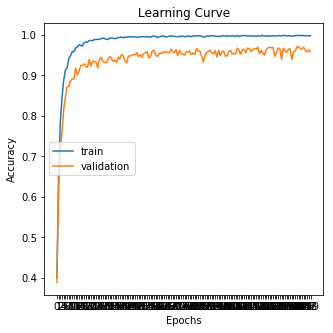

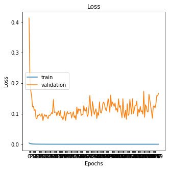

```python
import tensorflow as tf
import pathlib
from sklearn.utils import shuffle

# Adjusting learning rate
model_data_sets = [
             ('Model_augment2_conv3', 'model_augment2_conv3', 0.001)
            ]

# Hyperparameters
EPOCHS = 150
BATCH_SIZE = 512
keep_prob_value = 0.5 # Dropout
## Parameters for random weights/bias initialization
mu = 0
sigma = 0.1

for model, save_name, l_rate in model_data_sets:
    pathlib.Path(save_name + '_model').mkdir(parents=True, exist_ok=True)
    save_path = save_name + '_model/' + save_name + '.ckpt'

    # Placeholder
    x = tf.placeholder(tf.float32, (None, 32, 32, 3)) # Placeholder for train dataset
    y = tf.placeholder(tf.int32, (None)) # Placeholder for labels
    one_hot_y = tf.one_hot(y, nb_classes)
    keep_prob = tf.placeholder(tf.float32) # Dropout

    # Trainig pipeline
    logits = LeNet2(x, keep_prob, mu, sigma, 24, 64, 240, 168, conv3 = True)
    cross_entropy = tf.nn.softmax_cross_entropy_with_logits(labels=one_hot_y, logits=logits)
    loss_operation = tf.reduce_mean(cross_entropy)
    optimizer = tf.train.AdamOptimizer(learning_rate = l_rate)
    training_operation = optimizer.minimize(loss_operation)

    # Model evaluation
    correct_prediction = tf.equal(tf.argmax(logits, 1), tf.argmax(one_hot_y, 1))
    accuracy_operation = tf.reduce_mean(tf.cast(correct_prediction, tf.float32))

    print('Training with ', model, 'parameters.')
    saver = tf.train.Saver()
    train_acc_all, train_loss_all, valid_acc_all, valid_loss_all = train_model(X_train_aug, y_train_aug, X_valid_plain, y_valid, saver, save_path)
    # Plot learning curves and loss
    plot_learning(train_acc_all, valid_acc_all)
    plot_loss(train_loss_all, valid_loss_all)
    print('-'*60)
```

Compare with training same network with augmented histogram equalized images.

```python
# Applying augmentation to the dataset
X_train_hist_aug, y_train_hist_aug = flipping_symm_class(X_train_hist, y_train, [30,22,26], new_classes = None, flip_other=False, plot=False)
X_train_hist_aug, y_train_hist_aug = flipping_symm_class(X_train_hist_aug, y_train_hist_aug, [36,37,38,33,19,20], new_classes = [37,36,39,34,20,19], flip_other=True, plot=False)
X_train_hist_aug, y_train_hist_aug = rot_180(X_train_hist_aug, y_train_hist_aug, [32,41], plot=False)
X_train_hist_aug, y_train_hist_aug = rotate_bright(X_train_hist_aug, y_train_hist_aug, [24,27,23,28,29,0,42,40,6,32,30,22,37,36,19], plot=False)
```

```
Training with  Model_hist_augment_conv3 parameters.
Training...
EPOCH 1 ...
Training Accuracy = 0.289
Training Loss = 0.00551
Validation Accuracy = 0.271
Validation Loss = 0.00581
EPOCH 2 ...
Training Accuracy = 0.583
Training Loss = 0.00268
Validation Accuracy = 0.583
Validation Loss = 0.00273
EPOCH 3 ...
Training Accuracy = 0.713
Training Loss = 0.00185
Validation Accuracy = 0.724
Validation Loss = 0.00184
EPOCH 4 ...
Training Accuracy = 0.785
Training Loss = 0.00137
Validation Accuracy = 0.801
Validation Loss = 0.00133
EPOCH 5 ...
Training Accuracy = 0.826
Training Loss = 0.00110
Validation Accuracy = 0.824
Validation Loss = 0.00111
EPOCH 6 ...
Training Accuracy = 0.856
Training Loss = 0.00091
Validation Accuracy = 0.866
Validation Loss = 0.00087
EPOCH 7 ...
Training Accuracy = 0.875
Training Loss = 0.00079
Validation Accuracy = 0.873
Validation Loss = 0.00082
EPOCH 8 ...
Training Accuracy = 0.885
Training Loss = 0.00073
```

[output cut: 71 more lines]

```
Validation Loss = 0.00042
EPOCH 140 ...
Training Accuracy = 0.962
Training Loss = 0.00023
Validation Accuracy = 0.961
Validation Loss = 0.00049
EPOCH 150 ...
Training Accuracy = 0.948
Training Loss = 0.00037
Validation Accuracy = 0.942
Validation Loss = 0.00080

Max train accuracy:  0.964010618655 at EPOCH:  146
Max validation accuracy:  0.970975064096 at EPOCH:  107
Model saved
```

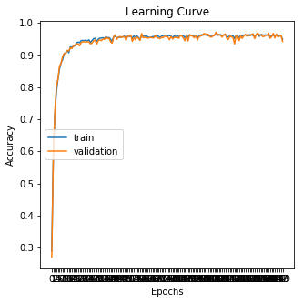

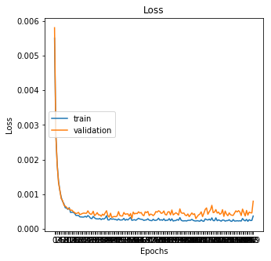

```python
import tensorflow as tf
import pathlib
from sklearn.utils import shuffle

# Adjusting learning rate
model_data_sets = [
             ('Model_hist_augment_conv3', 'model_hist_augment_conv3', 0.001)
            ]

# Hyperparameters
EPOCHS = 150
BATCH_SIZE = 512
keep_prob_value = 0.5 # Dropout
## Parameters for random weights/bias initialization
mu = 0
sigma = 0.1

for model, save_name, l_rate in model_data_sets:
    pathlib.Path(save_name + '_model').mkdir(parents=True, exist_ok=True)
    save_path = save_name + '_model/' + save_name + '.ckpt'

    # Placeholder
    x = tf.placeholder(tf.float32, (None, 32, 32, 3)) # Placeholder for train dataset
    y = tf.placeholder(tf.int32, (None)) # Placeholder for labels
    one_hot_y = tf.one_hot(y, nb_classes)
    keep_prob = tf.placeholder(tf.float32) # Dropout

    # Trainig pipeline
    logits = LeNet2(x, keep_prob, mu, sigma, 24, 64, 240, 168, conv3 = True)
    cross_entropy = tf.nn.softmax_cross_entropy_with_logits(labels=one_hot_y, logits=logits)
    loss_operation = tf.reduce_mean(cross_entropy)
    optimizer = tf.train.AdamOptimizer(learning_rate = l_rate)
    training_operation = optimizer.minimize(loss_operation)

    # Model evaluation
    correct_prediction = tf.equal(tf.argmax(logits, 1), tf.argmax(one_hot_y, 1))
    accuracy_operation = tf.reduce_mean(tf.cast(correct_prediction, tf.float32))

    print('Training with ', model, 'parameters.')
    saver = tf.train.Saver()
    train_acc_all, train_loss_all, valid_acc_all, valid_loss_all = train_model(X_train_hist_aug, y_train_hist_aug, X_valid_hist, y_valid, saver, save_path)
    # Plot learning curves and loss
    plot_learning(train_acc_all, valid_acc_all)
    plot_loss(train_loss_all, valid_loss_all)
    print('-'*60)
```

Doublng both dense layer neurons again and train with augmented RGB data (with former augmentation; no exceptions) again for more epochs + lower learninig rate.

```python
# Applying augmentation to the dataset
X_train_aug, y_train_aug = flipping_symm_class(X_train, y_train, [30,22,26], new_classes = None, flip_other=False, plot=False)
X_train_aug, y_train_aug = flipping_symm_class(X_train_aug, y_train_aug, [36,37,38,33,19,20], new_classes = [37,36,39,34,20,19], flip_other=True, plot=False)
X_train_aug, y_train_aug = rot_180(X_train_aug, y_train_aug, [32,41], plot=False)
X_train_aug, y_train_aug = rotate_bright(X_train_aug, y_train_aug, [24,27,23,28,29,0,42,21,40,6,16,32,41,30,22,37,36,20,19], plot=False)
# Normalizing
X_train_aug = normalize(X_train_aug)
```

```
Training with  Model_last parameters.
Training...
EPOCH 1 ...
Training Accuracy = 0.107
Training Loss = 0.00691
Validation Accuracy = 0.095
Validation Loss = 0.50618
EPOCH 2 ...
Training Accuracy = 0.245
Training Loss = 0.00584
Validation Accuracy = 0.235
Validation Loss = 0.59197
EPOCH 3 ...
Training Accuracy = 0.381
Training Loss = 0.00471
Validation Accuracy = 0.359
Validation Loss = 0.53150
EPOCH 4 ...
Training Accuracy = 0.481
Training Loss = 0.00384
Validation Accuracy = 0.448
Validation Loss = 0.46663
EPOCH 5 ...
Training Accuracy = 0.548
Training Loss = 0.00323
Validation Accuracy = 0.513
Validation Loss = 0.40779
EPOCH 6 ...
Training Accuracy = 0.600
Training Loss = 0.00278
Validation Accuracy = 0.558
Validation Loss = 0.35493
EPOCH 7 ...
Training Accuracy = 0.646
Training Loss = 0.00242
Validation Accuracy = 0.601
Validation Loss = 0.32785
EPOCH 8 ...
Training Accuracy = 0.682
Training Loss = 0.00215
```

[output cut: 146 more lines]

```
Validation Loss = 0.11241
EPOCH 290 ...
Training Accuracy = 0.999
Training Loss = 0.00001
Validation Accuracy = 0.954
Validation Loss = 0.12956
EPOCH 300 ...
Training Accuracy = 0.999
Training Loss = 0.00000
Validation Accuracy = 0.949
Validation Loss = 0.12292

Max train accuracy:  0.999410377358 at EPOCH:  293
Max validation accuracy:  0.958276646559 at EPOCH:  288
Model saved
```

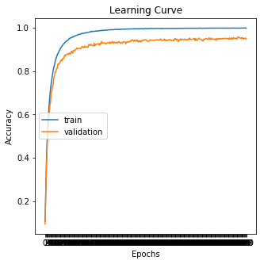

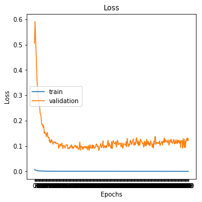

```python
import tensorflow as tf
import pathlib
from sklearn.utils import shuffle

# Adjusting learning rate
model_data_sets = [
             ('Model_last', 'model_last', 0.0001)
            ]

# Hyperparameters
EPOCHS = 300
BATCH_SIZE = 512
keep_prob_value = 0.5 # Dropout
## Parameters for random weights/bias initialization
mu = 0
sigma = 0.1

for model, save_name, l_rate in model_data_sets:
    pathlib.Path(save_name + '_model').mkdir(parents=True, exist_ok=True)
    save_path = save_name + '_model/' + save_name + '.ckpt'

    # Placeholder
    x = tf.placeholder(tf.float32, (None, 32, 32, 3)) # Placeholder for train dataset
    y = tf.placeholder(tf.int32, (None)) # Placeholder for labels
    one_hot_y = tf.one_hot(y, nb_classes)
    keep_prob = tf.placeholder(tf.float32) # Dropout

    # Trainig pipeline
    logits = LeNet2(x, keep_prob, mu, sigma, 24, 64, 480, 336, conv3 = True)
    cross_entropy = tf.nn.softmax_cross_entropy_with_logits(labels=one_hot_y, logits=logits)
    loss_operation = tf.reduce_mean(cross_entropy)
    optimizer = tf.train.AdamOptimizer(learning_rate = l_rate)
    training_operation = optimizer.minimize(loss_operation)

    # Model evaluation
    correct_prediction = tf.equal(tf.argmax(logits, 1), tf.argmax(one_hot_y, 1))
    accuracy_operation = tf.reduce_mean(tf.cast(correct_prediction, tf.float32))

    print('Training with ', model, 'parameters.')
    saver = tf.train.Saver()
    train_acc_all, train_loss_all, valid_acc_all, valid_loss_all = train_model(X_train_aug, y_train_aug, X_valid_plain, y_valid, saver, save_path)
    # Plot learning curves and loss
    plot_learning(train_acc_all, valid_acc_all)
    plot_loss(train_loss_all, valid_loss_all)
    print('-'*60)
```

Higher learning rate, BATCH_SIZE = 512, few more EPOCHS, dropout = 0.5, early_stopping = True.

```
Training with  Model_last2 parameters.
Training with early stopping.
Training...
EPOCH 1 ...
Training Accuracy = 0.136
Training Loss = 0.00648
Validation Accuracy = 0.134
Validation Loss = 0.00681
EPOCH 2 ...
Training Accuracy = 0.373
Training Loss = 0.00421
Validation Accuracy = 0.358
Validation Loss = 0.00451
EPOCH 3 ...
Training Accuracy = 0.541
Training Loss = 0.00288
Validation Accuracy = 0.515
Validation Loss = 0.00311
EPOCH 4 ...
Training Accuracy = 0.645
Training Loss = 0.00219
Validation Accuracy = 0.623
Validation Loss = 0.00240
EPOCH 5 ...
Training Accuracy = 0.725
Training Loss = 0.00168
Validation Accuracy = 0.699
Validation Loss = 0.00190
EPOCH 6 ...
Training Accuracy = 0.782
Training Loss = 0.00135
Validation Accuracy = 0.770
Validation Loss = 0.00146
EPOCH 7 ...
Training Accuracy = 0.819
Training Loss = 0.00113
Validation Accuracy = 0.798
Validation Loss = 0.00131
EPOCH 8 ...
Training Accuracy = 0.845
```

[output cut: 187 more lines]

```
Validation Loss = 0.00031
EPOCH 310 ...
Training Accuracy = 0.993
Training Loss = 0.00005
Validation Accuracy = 0.969
Validation Loss = 0.00046
EPOCH 320 ...
Training Accuracy = 0.997
Training Loss = 0.00002
Validation Accuracy = 0.975
Validation Loss = 0.00033

Max train accuracy:  0.997936320755 at EPOCH:  291
Max validation accuracy:  0.978911570438 at EPOCH:  247
Final model saved from epoch:  247   with Validation accuracy:  0.978911570438
```

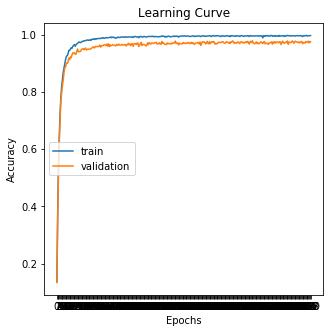

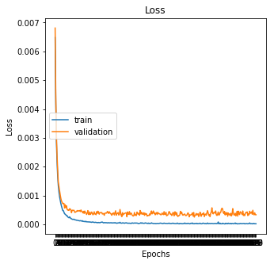

```python
import tensorflow as tf
import pathlib
from sklearn.utils import shuffle

# Adjusting learning rate
model_data_sets = [
             ('Model_last2', 'model_last2', 0.001)
            ]
nb_classes = 43
# Hyperparameters
EPOCHS = 320
BATCH_SIZE = 512
keep_prob_value = 0.5 # Dropout
## Parameters for random weights/bias initialization
mu = 0
sigma = 0.1

for model, save_name, l_rate in model_data_sets:
    pathlib.Path(save_name + '_model').mkdir(parents=True, exist_ok=True)
    save_path = save_name + '_model/' + save_name + '.ckpt'

    # Placeholder
    x = tf.placeholder(tf.float32, (None, 32, 32, 3)) # Placeholder for train dataset
    y = tf.placeholder(tf.int32, (None)) # Placeholder for labels
    one_hot_y = tf.one_hot(y, nb_classes)
    keep_prob = tf.placeholder(tf.float32) # Dropout

    # Trainig pipeline
    logits = LeNet2(x, keep_prob, mu, sigma, 24, 64, 240, 168, conv3 = True)
    cross_entropy = tf.nn.softmax_cross_entropy_with_logits(labels=one_hot_y, logits=logits)
    loss_operation = tf.reduce_mean(cross_entropy)
    optimizer = tf.train.AdamOptimizer(learning_rate = l_rate)
    training_operation = optimizer.minimize(loss_operation)

    # Model evaluation
    correct_prediction = tf.equal(tf.argmax(logits, 1), tf.argmax(one_hot_y, 1))
    accuracy_operation = tf.reduce_mean(tf.cast(correct_prediction, tf.float32))

    print('Training with ', model, 'parameters.')
    saver = tf.train.Saver()
    train_acc_all, train_loss_all, valid_acc_all, valid_loss_all = train_model(X_train_aug, y_train_aug, X_valid_plain, y_valid, saver, save_path, early_stopping = True)
    # Plot learning curves and loss
    plot_learning(train_acc_all, valid_acc_all)
    plot_loss(train_loss_all, valid_loss_all)
    print('-'*60)
```

Last evaluation on the **test** set.

```python
X_test_plain = normalize(X_test)
saver = tf.train.Saver()
with tf.Session() as sess:
    saver.restore(sess, './model_last2_model/model_last2.ckpt')
    valid_accuracy, valid_loss = evaluate(X_valid_plain, y_valid)
    print("Validation Accuracy = {:.3f}".format(valid_accuracy))

    test_accuracy, test_loss = evaluate(X_test_plain, y_test)
    print("Test = {:.5f}".format(test_accuracy))
```

```
Validation Accuracy = 0.980
Test = 0.95511
```

## Step 3: Test a Model on New Images

To give yourself more insight into how your model is working, download at least five pictures of German traffic signs from the web and use your model to predict the traffic sign type.

You may find `signnames.csv` useful as it contains mappings from the class id (integer) to the actual sign name.

### Load and Output the Images

```
Some example images, taken in switzerland.
```

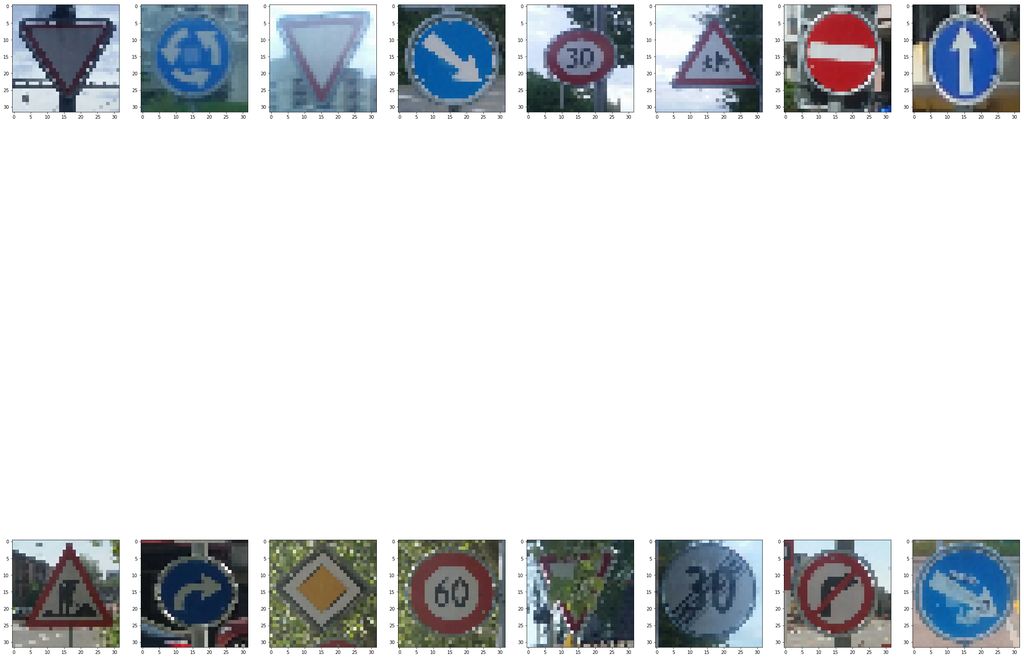

```python
### Load the images and plot them
print("Some example images, taken in switzerland.")
plt.figure(figsize=(40,40))
for i in range(len(X_test_own)):
    plt.subplot(2,len(X_test_own)//2,i+1)
    plt.imshow(cv2.cvtColor(X_test_own[i], cv2.COLOR_BGR2RGB))
plt.show()
```

### Predict the Sign Type for Each Image

```python
### Run the predictions here and use the model to output the prediction for each image
predic = []
y_test_own = np.array([])
X_test_own_plain = X_test_own.copy()
X_test_own_plain = normalize(X_test_own_plain)
_y = tf.nn.softmax(logits=logits)
saver = tf.train.Saver()
with tf.Session() as sess:
    checkpnt = tf.train.latest_checkpoint('./model_last2_model/')
    saver.restore(sess, './model_last2_model/model_last2.ckpt')
    valid_accuracy, valid_loss = evaluate(X_valid_plain, y_valid)
    print("Validation Accuracy = {:.3f}".format(valid_accuracy))

    for i in range(len(X_test_own_plain)):
        new_img = cv2.cvtColor(np.float32(X_test_own_plain[i]), cv2.COLOR_BGR2RGB)
        new_img = np.expand_dims(new_img,0)
        prediction = sess.run([_y],feed_dict={x: new_img, keep_prob: 1.0})
        predic.append(np.argmax(prediction))
print('New images classID prediction:')
print(predic)
```

```
Validation Accuracy = 0.978
New images classID prediction:
[13, 40, 13, 38, 1, 29, 17, 35, 25, 33, 12, 3, 13, 1, 20, 38]
```

### Analyze Performance

```python
from sklearn.metrics import f1_score
f1_score(y_test_own, predic, average='micro')
```

```
0.8125
```

Since in the test set are 2 images which don't belong to the training classes, the real accuracy should be **92.857%**.

### Output Top 5 Softmax Probabilities For Each Image Found on the Web

For each of the new images, print out the model's softmax probabilities to show the **certainty** of the model's predictions (limit the output to the top 5 probabilities for each image). [`tf.nn.top_k`](https://www.tensorflow.org/versions/r0.12/api_docs/python/nn.html#top_k) could prove helpful here.

The example below demonstrates how tf.nn.top_k can be used to find the top k predictions for each image.

`tf.nn.top_k` will return the values and indices (class ids) of the top k predictions. So if k=3, for each sign, it'll return the 3 largest probabilities (out of a possible 43) and the correspoding class ids.

Take this numpy array as an example. The values in the array represent predictions. The array contains softmax probabilities for five candidate images with six possible classes. `tf.nn.top_k` is used to choose the three classes with the highest probability:

```
# (5, 6) array
a = np.array([[ 0.24879643,  0.07032244,  0.12641572,  0.34763842,  0.07893497,
         0.12789202],
       [ 0.28086119,  0.27569815,  0.08594638,  0.0178669 ,  0.18063401,
         0.15899337],
       [ 0.26076848,  0.23664738,  0.08020603,  0.07001922,  0.1134371 ,
         0.23892179],
       [ 0.11943333,  0.29198961,  0.02605103,  0.26234032,  0.1351348 ,
         0.16505091],
       [ 0.09561176,  0.34396535,  0.0643941 ,  0.16240774,  0.24206137,
         0.09155967]])
```

Running it through `sess.run(tf.nn.top_k(tf.constant(a), k=3))` produces:

```
TopKV2(values=array([[ 0.34763842,  0.24879643,  0.12789202],
       [ 0.28086119,  0.27569815,  0.18063401],
       [ 0.26076848,  0.23892179,  0.23664738],
       [ 0.29198961,  0.26234032,  0.16505091],
       [ 0.34396535,  0.24206137,  0.16240774]]), indices=array([[3, 0, 5],
       [0, 1, 4],
       [0, 5, 1],
       [1, 3, 5],
       [1, 4, 3]], dtype=int32))
```

Looking just at the first row we get `[ 0.34763842, 0.24879643, 0.12789202]`, you can confirm these are the 3 largest probabilities in `a`. You'll also notice `[3, 0, 5]` are the corresponding indices.

```
Validation Accuracy = 0.978
```

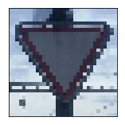

```
Label:  Yield | Probability:  1.0
Label:  Speed limit (60km/h) | Probability:  1.013e-33
Label:  End of all speed and passing limits | Probability:  1.89889e-34
Label:  No vehicles | Probability:  8.79386e-36
Label:  Bumpy road | Probability:  1.91168e-37
```

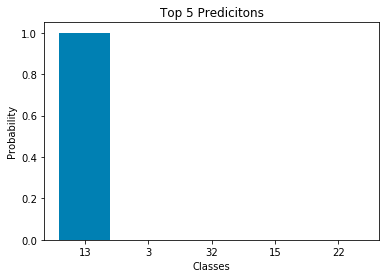

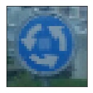

```
Label:  Roundabout mandatory | Probability:  1.0
Label:  Go straight or right | Probability:  3.4504e-22
Label:  Go straight or left | Probability:  1.30839e-22
Label:  Keep right | Probability:  1.05869e-23
Label:  Keep left | Probability:  7.56184e-27
```

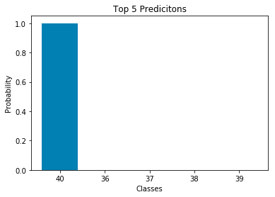

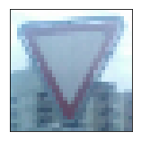

```
Label:  Yield | Probability:  1.0
Label:  Keep left | Probability:  8.77021e-09
Label:  End of all speed and passing limits | Probability:  1.73555e-09
Label:  Speed limit (60km/h) | Probability:  2.82936e-10
Label:  Go straight or left | Probability:  6.50127e-11
```

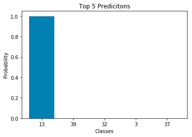

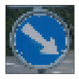

```
Label:  Keep right | Probability:  1.0
Label:  Speed limit (20km/h) | Probability:  0.0
Label:  Speed limit (30km/h) | Probability:  0.0
Label:  Speed limit (50km/h) | Probability:  0.0
Label:  Speed limit (60km/h) | Probability:  0.0
```

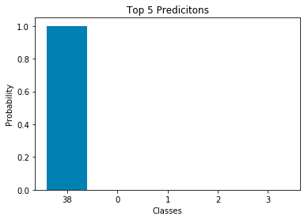

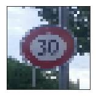

```
Label:  Speed limit (30km/h) | Probability:  0.705905
Label:  Speed limit (70km/h) | Probability:  0.252203
Label:  Roundabout mandatory | Probability:  0.0372862
Label:  No vehicles | Probability:  0.00172004
Label:  Speed limit (50km/h) | Probability:  0.00129603
```

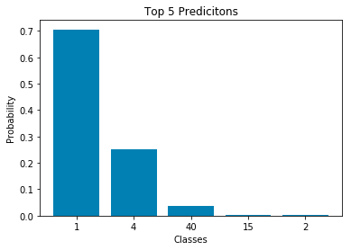

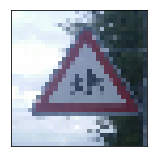

```
Label:  Bicycles crossing | Probability:  0.871604
Label:  Children crossing | Probability:  0.114172
Label:  Beware of ice/snow | Probability:  0.012635
Label:  Speed limit (20km/h) | Probability:  0.00116463
Label:  Speed limit (30km/h) | Probability:  0.000234242
```

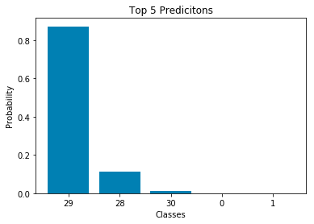

[20 more figures not shown]

```python
### Print out the top five softmax probabilities for the predictions on the German traffic sign images found on the web
## Feel free to use as many code cells as needed
### Run the predictions here and use the model to output the prediction for each image
labels = pd.read_csv('signnames.csv', sep=',', index_col='ClassId')
X_test_own_plain = normalize(X_test_own)
_y = tf.nn.softmax(logits=logits)
saver = tf.train.Saver()
with tf.Session() as sess:
    checkpnt = tf.train.latest_checkpoint('./model_last2_model/')
    saver.restore(sess, './model_last2_model/model_last2.ckpt')
    valid_accuracy, valid_loss = evaluate(X_valid_plain, y_valid)
    print("Validation Accuracy = {:.3f}".format(valid_accuracy))

    for i in range(len(X_test_own_plain)):
        new_img = cv2.cvtColor(np.float32(X_test_own_plain[i]), cv2.COLOR_BGR2RGB)
        new_img = np.expand_dims(new_img,0)
        prediction = sess.run([_y],feed_dict={x: new_img, keep_prob: 1.0})
        prob_top_5 = sess.run(tf.nn.top_k(tf.constant(prediction[0]), k=5))
        plt.figure(figsize=(2.5,2.5))
        plt.xticks([])
        plt.yticks([])
        plt.imshow(cv2.cvtColor(X_test_own[i], cv2.COLOR_BGR2RGB))
        plt.show()
        [print('Label: ', labels['SignName'][prob_top_5[1][0][i]], '| Probability: ', prob_top_5[0][0][i]) for i in range(5)]
        plt.bar(np.arange(5), prob_top_5[0][0], align='center', color=(0,0.5,0.7))
        plt.xticks(np.arange(5), prob_top_5[1][0])
        plt.ylabel('Probability')
        plt.xlabel('Classes')
        plt.title('Top 5 Predicitons')
        plt.show()
        print('-'*60)
```

## Step 4 (Optional): Visualize the Neural Network's State with Test Images

This Section is not required to complete but acts as an additional excersise for understaning the output of a neural network's weights. While neural networks can be a great learning device they are often referred to as a black box. We can understand what the weights of a neural network look like better by plotting their feature maps. After successfully training your neural network you can see what it's feature maps look like by plotting the output of the network's weight layers in response to a test stimuli image. From these plotted feature maps, it's possible to see what characteristics of an image the network finds interesting. For a sign, maybe the inner network feature maps react with high activation to the sign's boundary outline or to the contrast in the sign's painted symbol.

Provided for you below is the function code that allows you to get the visualization output of any tensorflow weight layer you want. The inputs to the function should be a stimuli image, one used during training or a new one you provided, and then the tensorflow variable name that represents the layer's state during the training process, for instance if you wanted to see what the LeNet lab's feature maps looked like for it's second convolutional layer you could enter conv2 as the tf_activation variable.

For an example of what feature map outputs look like, check out NVIDIA's results in their paper [End-to-End Deep Learning for Self-Driving Cars](https://devblogs.nvidia.com/parallelforall/deep-learning-self-driving-cars/) in the section Visualization of internal CNN State. NVIDIA was able to show that their network's inner weights had high activations to road boundary lines by comparing feature maps from an image with a clear path to one without. Try experimenting with a similar test to show that your trained network's weights are looking for interesting features, whether it's looking at differences in feature maps from images with or without a sign, or even what feature maps look like in a trained network vs a completely untrained one on the same sign image.

[figure not shown]

Your output should look something like this (above)

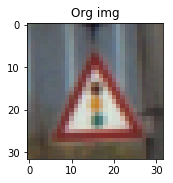

```
Layer 1 Activation.
```

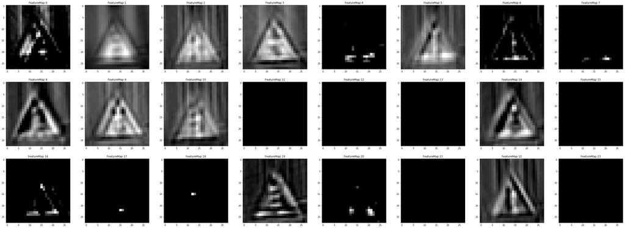

```
Layer 2 Activation.
```

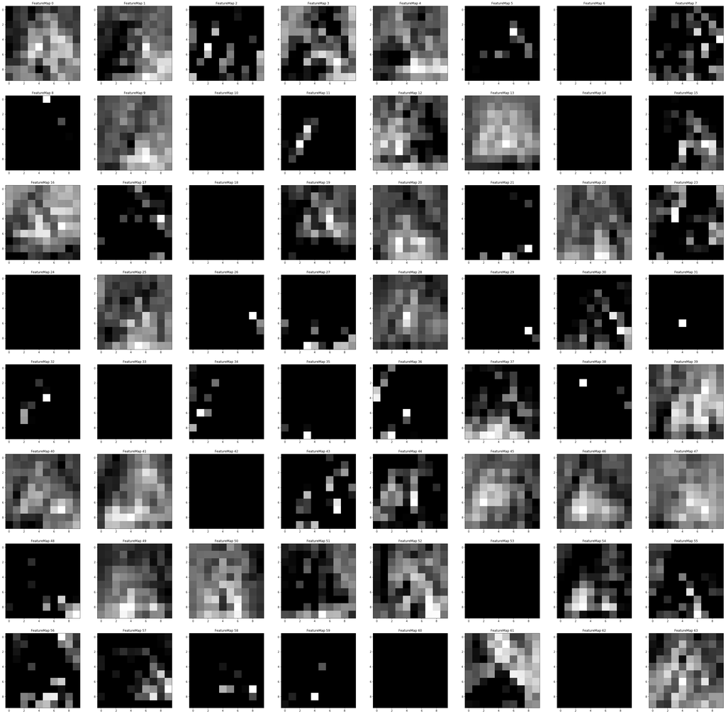

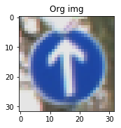

```
Layer 1 Activation.
```

[figure not shown]

```
Layer 2 Activation.
```

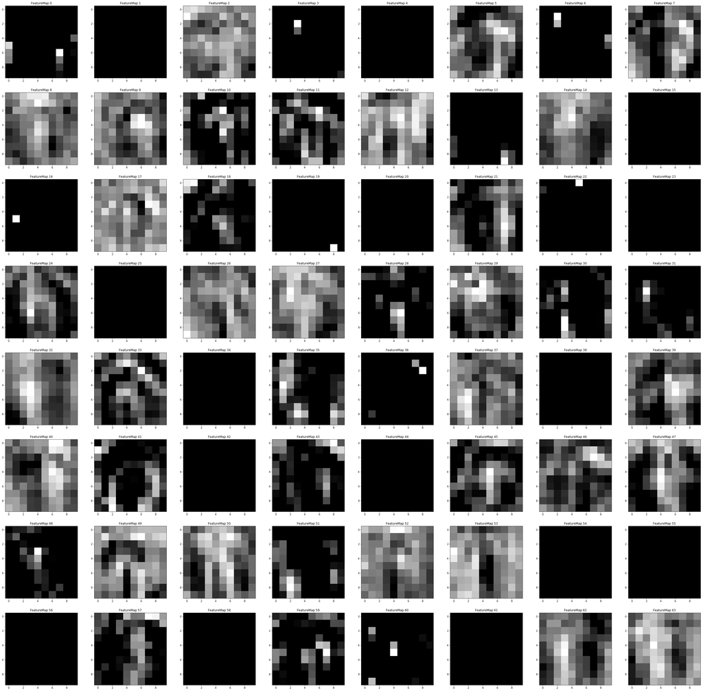

```python
### Visualize your network's feature maps here.

# image_input: the test image being fed into the network to produce the feature maps
# tf_activation: should be a tf variable name used during your training procedure that represents the calculated state of a specific weight layer
# activation_min/max: can be used to view the activation contrast in more detail, by default matplot sets min and max to the actual min and max values of the output
# plt_num: used to plot out multiple different weight feature map sets on the same block, just extend the plt number for each new feature map entry

def outputFeatureMap(image_input, tf_activation, activation_min=-1, activation_max=-1 ,plt_num=1):
    with tf.Session() as sess:
        sess.run(tf.global_variables_initializer())
        saver = tf.train.import_meta_graph('model_last2.meta')
        saver.restore(sess, tf.train.latest_checkpoint('./'))

        activation = tf_activation.eval(session=sess,feed_dict={x : image_input})
        featuremaps = activation.shape[3]
        plt.figure(plt_num, figsize=(50,50))
        for featuremap in range(featuremaps):
            plt.subplot(8,8, featuremap+1) # sets the number of feature maps to show on each row and column
            plt.title('FeatureMap ' + str(featuremap)) # displays the feature map number
            if activation_min != -1 & activation_max != -1:
                plt.imshow(activation[0,:,:, featuremap], interpolation="nearest", vmin =activation_min, vmax=activation_max, cmap="gray")
            elif activation_max != -1:
                plt.imshow(activation[0,:,:, featuremap], interpolation="nearest", vmax=activation_max, cmap="gray")
            elif activation_min !=-1:
                plt.imshow(activation[0,:,:, featuremap], interpolation="nearest", vmin=activation_min, cmap="gray")
            else:
                plt.imshow(activation[0,:,:, featuremap], interpolation="nearest", cmap="gray")
        plt.show()

def activation_examples(img):
    activa = LeNet2(x, keep_prob, filter1=24, filter2=64, conv3 = True, activ0 = True)
    new_img = normalize(img)
    plt.figure(figsize=(2.5,2.5))
    plt.title('Org img')
    plt.imshow(new_img)
    plt.show()
    new_img = np.expand_dims(new_img,0)
    print('Layer 1 Activation.')
    outputFeatureMap(new_img, activa)
    activa2 = LeNet2(x, keep_prob, filter1=24, filter2=64, conv3 = True, activ1 = True)
    print('Layer 2 Activation.')
    outputFeatureMap(new_img, activa2)

# Example 1
activation_examples(X_train[1400])
# Example 2
activation_examples(X_train[20000])
```